# Efficacy in Financial Rulemaking

## Efficacy

### Efficacy by Assets

These models have the prefix `me_`. The dependent variable is the efficacy score.

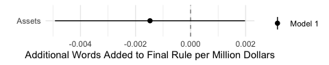

```r
# broken out by org type

mea_assets <- lm(efficacy ~ assets,
           data = e  %>% mutate(assets = assets/1000000))

mea_opensecrets <- glm(efficacy ~ MeanContribAmount,
           data = e %>% mutate(MeanContribAmount = MeanContribAmount/1000))

mea_marketcap <- glm(efficacy ~ marketcap2,
           data = e  %>% mutate(marketcap2 = marketcap2/1000000))

models <- list(mea_assets, mea_opensecrets, mea_marketcap)

# FIXME
#modelsummary(models)

modelplot( mea_assets) +
  labs(x = "Additional Words Added to Final Rule per Million Dollars")
```

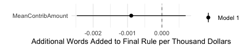

```r
modelplot( mea_opensecrets) +
  labs(x = "Additional Words Added to Final Rule per Thousand Dollars")
```

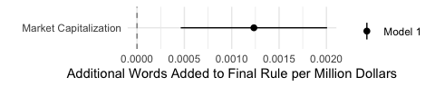

```r
modelplot(mea_marketcap) +
  labs(x = "Additional Words Added to Final Rule per Million Dollars")
```

### Efficacy by Sophistication

These models have the prefix `mes_`. The dependent variable is the efficacy score.

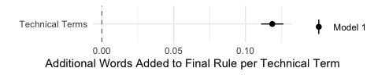

```r
mes_bluebook <- lm(efficacy ~ Total_Legal_Citations,
           data = d )

mes_terms <- glm(efficacy ~ dictionary_terms,
           data = d)

mes_terms_bluebook <- glm(efficacy ~ dictionary_terms + Total_Legal_Citations,
           data = d )

models <- list(mes_terms , mes_bluebook , mes_terms_bluebook )

rows <- tibble(
  term = c("Dependent Variable"),
  `1` = "Efficacy",
   `2` = "Efficacy",
  `3` = "Efficacy"
)

attr(rows, 'position') <- c(0)


# FIXME
# modelsummary(models)#, gof_map = gm)

modelplot(mes_terms) +
  labs(x = "Additional Words Added to Final Rule per Technical Term")
```

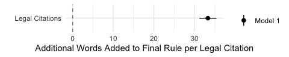

```r
modelplot( mes_bluebook ) +
  labs(x = "Additional Words Added to Final Rule per Legal Citation")
```

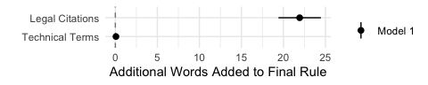

```r
modelplot(mes_terms_bluebook ) +
  labs(x = "Additional Words Added to Final Rule")
```

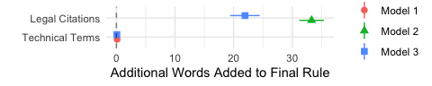

```r
modelplot(models) +
  labs(x = "Additional Words Added to Final Rule")
```

## Efficacy by Assets Mediated by Sophistication

To assess sophistication as a mediator between wealth and the influence of public comments on rules (efficacy), we estimate the average conditional marginal effect (ACME, conditional on the the number of technical terms or legal citations) and average direct effect (ADE) of wealth using mediation analysis.

These models have the prefix `mem_`. The dependent variable is the efficacy score. The mediator is technical terms.

### Assets x legal citations

```r
library(mediation)


# model predicting mediator, sophistication
model.m <- lm(Total_Legal_Citations ~ assets,
              data = b  %>% mutate(assets = assets/10000000000) %>%
                drop_na(Total_Legal_Citations, efficacy))

# model predicting DV
model.y <- glm(efficacy ~ Total_Legal_Citations + assets,
               data = b  %>% mutate(assets = assets/10000000000))

models <- list(model.m, model.y)

rows <- tibble(
  term = c("Dependent Variable"),
  `1` = "Legal Citations",
   `2` = "Efficacy",
)

attr(rows, 'position') <- c(0)


modelsummary(models)
```

|  | Model 1 | Model 2 |
| --- | --- | --- |
| Dependent Variable | Legal Citations | Efficacy |
| Assets | −0.513 | −8.676 |
|  | (0.647) | (15.860) |
| Legal Citations |  | 11.826*** |
|  |  | (0.616) |
| Num.Obs. | 1584 | 1584 |
| R2 | 0.000 |  |
| R2 Adj. | 0.000 |  |
| AIC | 12103.9 | 22238.8 |
| BIC | 12120.0 | 22260.3 |
| Log.Lik. | −6048.926 | −11115.423 |
| F | 0.629 |  |
| RMSE | 11.03 | 270.24 |

+ p < 0.1, * p < 0.05, ** p < 0.01, *** p < 0.001

```r
med.cont <- mediate(model.m, model.y, sims=1000, treat = "assets",
mediator = "Total_Legal_Citations")

summary(med.cont)
```

```
##
## Causal Mediation Analysis
##
## Quasi-Bayesian Confidence Intervals
##
##                Estimate 95% CI Lower 95% CI Upper p-value
## ACME             -5.789      -19.996         7.82    0.45
## ADE              -8.045      -38.955        24.06    0.60
## Total Effect    -13.835      -46.883        21.39    0.44
## Prop. Mediated    0.281       -3.472         3.83    0.55
##
## Sample Size Used: 1584
##
##
## Simulations: 1000
```

### Assets x technical terms

```r
# model predicting mediator, sophistication
model.m <- lm(dictionary_terms ~ assets,
              data = b  %>% mutate(assets = assets/10000000000) %>%
                drop_na(dictionary_terms, efficacy))

# model predicting DV
model.y <- glm(efficacy ~ dictionary_terms + assets,
               data = b  %>% mutate(assets = assets/10000000000))

models <- list(model.m, model.y)

rows <- tibble(
  term = c("Dependent Variable"),
  `1` = "Technical Terms",
   `2` = "Efficacy",
)

attr(rows, 'position') <- c(0)


modelsummary(models)
```

|  | Model 1 | Model 2 |
| --- | --- | --- |
| Dependent Variable | Technical Terms | Efficacy |
| Assets | −100.512 | −5.367 |
|  | (128.520) | (12.890) |
| Technical Terms |  | 0.093*** |
|  |  | (0.003) |
| Num.Obs. | 1584 | 1584 |
| R2 | 0.000 |  |
| R2 Adj. | 0.000 |  |
| AIC | 28866.9 | 21582.0 |
| BIC | 28883.0 | 21603.5 |
| Log.Lik. | −14430.456 | −10787.024 |
| F | 0.612 |  |
| RMSE | 2190.38 | 219.64 |

+ p < 0.1, * p < 0.05, ** p < 0.01, *** p < 0.001

```r
med.cont <- mediate(model.m, model.y, sims=1000, treat = "assets",
mediator = "dictionary_terms")

summary(med.cont)
```

```
##
## Causal Mediation Analysis
##
## Quasi-Bayesian Confidence Intervals
##
##                Estimate 95% CI Lower 95% CI Upper p-value
## ACME             -9.046      -31.670         14.6    0.41
## ADE              -5.705      -31.900         19.4    0.70
## Total Effect    -14.751      -47.202         18.6    0.37
## Prop. Mediated    0.527       -3.338          5.6    0.38
##
## Sample Size Used: 1584
##
##
## Simulations: 1000
```

### Market cap x legal citations

```r
# model predicting mediator, sophistication
model.m <- lm(Total_Legal_Citations ~ marketcap2,
              data = b  %>% mutate(marketcap2 = marketcap2/10000000000) %>%
                drop_na(Total_Legal_Citations, efficacy))

# model predicting DV
model.y <- glm(efficacy ~ Total_Legal_Citations + marketcap2,
               data = b  %>% mutate(assets = marketcap2/10000000000))

models <- list(model.m, model.y)

rows <- tibble(
  term = c("Dependent Variable"),
  `1` = "Legal Citations",
   `2` = "Efficacy",
)

attr(rows, 'position') <- c(0)


modelsummary(models)
```

|  | Model 1 | Model 2 |
| --- | --- | --- |
| Dependent Variable | Legal Citations | Efficacy |
| Market Capitalization | 0.174** | 0.000+ |
|  | (0.064) | (0.000) |
| Legal Citations |  | 33.622*** |
|  |  | (4.219) |
| Num.Obs. | 151 | 151 |
| R2 | 0.047 |  |
| R2 Adj. | 0.041 |  |
| AIC | 967.7 | 2159.0 |
| BIC | 976.7 | 2171.1 |
| Log.Lik. | −480.847 | −1075.518 |
| F | 7.342 |  |
| RMSE | 5.88 | 303.00 |

+ p < 0.1, * p < 0.05, ** p < 0.01, *** p < 0.001

```r
med.cont <- mediate(model.m, model.y, sims=1000, treat = "marketcap2",
mediator = "Total_Legal_Citations")

summary(med.cont)
```

```
##
## Causal Mediation Analysis
##
## Quasi-Bayesian Confidence Intervals
##
##                        Estimate     95% CI Lower 95% CI Upper
## ACME           5.89410464106481 1.41980845582105         10.4
## ADE            0.00000000063909 0.00000000000313          0.0
## Total Effect   5.89410464170390 1.41980845593367         10.4
## Prop. Mediated 0.99999999989371 0.99999999954715          1.0
##                            p-value
## ACME                         0.004 **
## ADE                          0.050 *
## Total Effect                 0.004 **
## Prop. Mediated <0.0000000000000002 ***
## ---
## Signif. codes:  0 '***' 0.001 '**' 0.01 '*' 0.05 '.' 0.1 ' ' 1
##
## Sample Size Used: 151
##
##
## Simulations: 1000
```

### Market cap x technical terms

```r
# model predicting mediator, sophistication
model.m <- lm(dictionary_terms ~ marketcap2,
              data = b  %>% mutate(marketcap2 = marketcap2/10000000000) %>%
                drop_na(dictionary_terms, efficacy))

# model predicting DV
model.y <- glm(efficacy ~ dictionary_terms + marketcap2,
               data = b  %>% mutate(marketcap2 = marketcap2/10000000000))

models <- list(model.m, model.y)

rows <- tibble(
  term = c("Dependent Variable"),
  `1` = "Technical Terms",
   `2` = "Efficacy",
)

attr(rows, 'position') <- c(0)


modelsummary(models)
```

|  | Model 1 | Model 2 |
| --- | --- | --- |
| Dependent Variable | Technical Terms | Efficacy |
| Market Capitalization | 65.653** | 3.842 |
|  | (23.149) | (2.637) |
| Technical Terms |  | 0.129*** |
|  |  | (0.009) |
| Num.Obs. | 151 | 151 |
| R2 | 0.051 |  |
| R2 Adj. | 0.045 |  |
| AIC | 2745.6 | 2082.6 |
| BIC | 2754.7 | 2094.7 |
| Log.Lik. | −1369.825 | −1037.315 |
| F | 8.044 |  |
| RMSE | 2120.52 | 235.27 |

+ p < 0.1, * p < 0.05, ** p < 0.01, *** p < 0.001

```r
med.cont <- mediate(model.m, model.y, sims=1000, treat = "marketcap2",
mediator = "dictionary_terms")

summary(med.cont)
```

```
##
## Causal Mediation Analysis
##
## Quasi-Bayesian Confidence Intervals
##
##                Estimate 95% CI Lower 95% CI Upper             p-value
## ACME              8.700        2.984        15.20               0.002 **
## ADE               3.862       -1.164         9.04               0.148
## Total Effect     12.561        4.897        20.49 <0.0000000000000002 ***
## Prop. Mediated    0.694        0.385         1.17               0.002 **
## ---
## Signif. codes:  0 '***' 0.001 '**' 0.01 '*' 0.05 '.' 0.1 ' ' 1
##
## Sample Size Used: 151
##
##
## Simulations: 1000
```

# TODO

- split out FDIC banks and nonprofits in asset mediation analysis? (at the moment, neither type of assets are correlated with efficacy, so mediation analysis is a low priority)
- Try to get efficacy measures for key obaservations. For example, cases where we have market cap:

Observations for which we have market cap and sophistication but are missing efficacy measures:

```r
b %>% drop_na(marketcap, Total_Legal_Citations) %>%
  arrange(-Total_Legal_Citations) %>%
  filter(is.na(efficacy)) %>%
  dplyr::select(efficacy,marketcap, Total_Legal_Citations, org_name, comment_url) %>%
  kablebox()
```

| efficacy | marketcap | Total_Legal_Citations | org_name | comment_url |
| --- | --- | --- | --- | --- |
| NA | 81.203B | 28 | pnc financial services | https://comments.cftc.gov/PublicComments/ViewComment.aspx?id=56654 |
| NA | 183.806B | 19 | morgan stanley | https://www.sec.gov/comments/s7-08-12/s70812-4663173-176545.pdf |
| NA | 157.755B | 19 | nextera energy | https://comments.cftc.gov/PublicComments/ViewComment.aspx?id=50461 |
| NA | 157.755B | 19 | nextera energy | https://comments.cftc.gov/PublicComments/ViewComment.aspx?id=50454 |
| NA | 157.755B | 19 | nextera energy | https://comments.cftc.gov/PublicComments/ViewComment.aspx?id=50457 |
| NA | 157.755B | 19 | nextera energy | https://comments.cftc.gov/PublicComments/ViewComment.aspx?id=50459 |
| NA | 157.755B | 19 | nextera energy | https://comments.cftc.gov/PublicComments/ViewComment.aspx?id=50460 |
| NA | 157.755B | 19 | nextera energy | https://comments.cftc.gov/PublicComments/ViewComment.aspx?id=50456 |
| NA | 157.755B | 19 | nextera energy | https://comments.cftc.gov/PublicComments/ViewComment.aspx?id=50455 |
| NA | 157.755B | 19 | nextera energy | https://comments.cftc.gov/PublicComments/ViewComment.aspx?id=50462 |
| NA | 157.755B | 19 | nextera energy | https://comments.cftc.gov/PublicComments/ViewComment.aspx?id=50463 |
| NA | 157.755B | 19 | nextera energy | https://comments.cftc.gov/PublicComments/ViewComment.aspx?id=50458 |
| NA | 135.268B | 13 | american express | https://comments.cftc.gov/PublicComments/ViewComment.aspx?id=56677 |
| NA | 183.806B | 12 | morgan stanley | https://www.sec.gov/comments/s7-38-11/s73811-25.pdf |
| NA | 183.806B | 12 | morgan stanley | https://www.federalreserve.gov/SECRS/2011/August/20110812/R-1417/R-1417_072211_84735_400774047765_1.pdf |
| NA | 81.203B | 11 | pnc financial services | https://comments.cftc.gov/PublicComments/ViewComment.aspx?id=57240 |
| NA | 66.475B | 11 | intercontinental exchange | https://comments.cftc.gov/PublicComments/ViewComment.aspx?id=60929 |
| NA | 66.475B | 11 | intercontinental exchange | https://comments.cftc.gov/PublicComments/ViewComment.aspx?id=61105 |
| NA | 41.51B | 10 | prudential financial | https://www.federalreserve.gov/SECRS/2016/October/20161012/R-1540/R-1540_081716_130449_332400080474_1.pdf |
| NA | 183.806B | 10 | morgan stanley | https://comments.cftc.gov/PublicComments/ViewComment.aspx?id=61227 |
| NA | 183.806B | 10 | morgan stanley | https://comments.cftc.gov/PublicComments/ViewComment.aspx?id=48426 |
| NA | 183.806B | 9 | morgan stanley | https://www.sec.gov/comments/s7-08-12/s70812-32.pdf |
| NA | 44.46B | 9 | american international | https://comments.cftc.gov/PublicComments/ViewComment.aspx?id=56940 |
| NA | 1.465B | 8 | encore capital | https://www.regulations.gov/comment/CFPB-2013-0033-0297 |
| NA | 183.806B | 8 | morgan stanley | https://comments.cftc.gov/PublicComments/ViewComment.aspx?id=56640 |
| NA | 7.662B | 7 | old republic international | https://www.regulations.gov/comment/CFPB-2012-0028-1193 |
| NA | 183.806B | 7 | morgan stanley | https://www.sec.gov/comments/s7-14-11/s71411-172.pdf |
| NA | 31.111B | 7 | state street | https://comments.cftc.gov/PublicComments/ViewComment.aspx?id=59086 |
| NA | 7.066B | 7 | plains all american pipeline | https://comments.cftc.gov/PublicComments/ViewComment.aspx?id=59664 |
| NA | 183.806B | 6 | morgan stanley | https://www.sec.gov/comments/s7-08-12/s70812-70.pdf |

[output cut: 270 more lines]